# Lab Report 2

**Research question 1**: Can we observe a masked priming effect (in a non-native language)?

**Research question 2**: If there is a masked priming effect, does it increase, decrease, or stay the same after a short period of time (80 ms)?

**Research question 3**: If there is a masked priming effect, is there also a semantic priming effect (in the incongruent pairs)?

Other things to check:

- did participants improve over time (both within blocks and over all trials)?
- did it make a difference whether participants were in block A or block B (short SOA then long vs. long SOA then short)?
- ???

Two main communications: short and long Stimulus Onset Asynchrony (SOA)

- Fixation: ###### 539 ms
- Mask: ##### 32 ms
- Prime: 32 ms
- Mask: ##### 32 ms
- (short SOA condition): 0 ms break. Proceed directly to target
- (long condition): Blank screen: 80 ms
- Target: timeout after 2000 ms

Approx. half the participants saw the short SOA first (group A), and half saw the long SOA first (group B).

Congruent and Incongruent stimuli were fully randomised within each SOA block

Stimuli were taken from:

Peel, H. J., Royals, K. A., & Chouinard, P. A. (2022). The effects of word identity, case, and SOA on word priming in a subliminal context. *Journal of Psycholinguistic Research, 51*(1), 1-15.

```python
# Setup

import numpy as np
import pandas as pd
import pingouin as pg
import seaborn as sns
import matplotlib.pyplot as plt

import warnings
warnings.filterwarnings('ignore')
```

Combine the group A and group B data

```python
rawA = 'https://raw.githubusercontent.com/ethanweed/ExPsyLing/master/datasets/Masked_repetition_priming/MR_A.csv'
rawB = 'https://raw.githubusercontent.com/ethanweed/ExPsyLing/master/datasets/Masked_repetition_priming/MR_B.csv'

raw_a = pd.read_csv(rawA)
raw_b = pd.read_csv(rawB)

df_A = pd.DataFrame({"id": raw_a['jatosStudyResultId'],
                     "counter_balance": raw_a['counterbalance'],
                     "condition": raw_a['condition'],
                     "rt": raw_a['response_time'],
                     "congruence": raw_a['congruence'],
                     "soa": raw_a['soa_condition'],
                     "correct": raw_a['correct']})
df_A = df_A.loc[df_A['soa'] != 'practice']
df_A.head()


df_B = pd.DataFrame({"id": raw_b['jatosStudyResultId'],
                     "counter_balance": raw_b['counterbalance'],
                     "condition": raw_b['condition'],
                     "rt": raw_b['response_time'],
                     "congruence": raw_b['congruence'],
                     "soa": raw_b['soa_condition'],
                     "correct": raw_b['correct']})
df_B = df_B.loc[df_B['soa'] != 'practice']
df_B.head()

df = pd.concat([df_A,df_B])
df.head(20)
```

|  | id | counter_balance | condition | rt | congruence | soa | correct |
| --- | --- | --- | --- | --- | --- | --- | --- |
| 4 | 799 | A | Con_Synth | 824 | congruent | short | 1 |
| 5 | 799 | A | Con_Nat | 796 | congruent | short | 1 |
| 6 | 799 | A | Inc_Synth_Synth | 881 | incongruent | short | 0 |
| 7 | 799 | A | Con_Synth | 1243 | congruent | short | 1 |
| 8 | 799 | A | Con_Nat | 1956 | congruent | short | 1 |
| 9 | 799 | A | Con_Synth | 1963 | congruent | short | 1 |
| 10 | 799 | A | Inc_Synth_Synth | 1112 | incongruent | short | 0 |
| 11 | 799 | A | Con_Nat | 1257 | congruent | short | 1 |
| 12 | 799 | A | Con_Nat | 1043 | congruent | short | 1 |
| 13 | 799 | A | Inc_Nat_Nat | 2019 | incongruent | short | 0 |
| 14 | 799 | A | Inc_Synth_Nat | 1127 | incongruent | short | 0 |
| 15 | 799 | A | Con_Nat | 957 | congruent | short | 1 |
| 16 | 799 | A | Con_Nat | 874 | congruent | short | 1 |
| 17 | 799 | A | Con_Nat | 1252 | congruent | short | 1 |
| 18 | 799 | A | Con_Nat | 749 | congruent | short | 1 |
| 19 | 799 | A | Inc_Nat_Synth | 1204 | incongruent | short | 1 |
| 20 | 799 | A | Inc_Synth_Synth | 688 | incongruent | short | 0 |
| 21 | 799 | A | Con_Nat | 881 | congruent | short | 1 |
| 22 | 799 | A | Con_Nat | 2001 | congruent | short | 0 |
| 23 | 799 | A | Con_Synth | 1028 | congruent | short | 1 |

```python
#df.reset_index(inplace = True)
```

```python
# fixing various things
df.replace(to_replace = 'Nat_Nat_Synth', value = 'Inc_Nat_Nat', inplace = True)

# split data into conditions that are okay (i.e., NOT conditions that need fixing) and conditions that need fixing
df_ok = df.loc[(df['condition'] != 'Inc_Synth_Synth') & (df['condition'] != 'Inc_Nat_Nat')]
df_fix = df.loc[(df['condition'] == 'Inc_Synth_Synth') | (df['condition'] == 'Inc_Nat_Nat')]

# fix the data that needs fixing - when it is 1 it should be 0, and when it is not 1 (i.e. 0) it should be 1
df_fix['correct'] = np.where(df_fix['correct'] == 1, 0, 1)

# put the data back together again
df = pd.concat([df_ok, df_fix])
df.head()

# adding trial
df['id'].value_counts()

trial = list(range(1,121))
trial = trial*len(df['id'].unique())

df['trial'] = trial
```

```python
raw_a.columns
```

```
Index(['browser_codename', 'browser_name', 'browser_version', 'condition',
       'congruence', 'correct', 'counterbalance', 'date_startdate',
       'date_startdateUTC', 'date_starttime', 'experiment_debug',
       'experiment_parameters', 'experiment_pilot', 'experiment_taskname',
       'experiment_taskversion', 'jatosStudyResultId', 'jatosVersion', 'prime',
       'queryParams_batchId', 'queryParams_generalMultiple', 'response_time',
       'screen_availableHeight', 'screen_availableWidth', 'screen_colorDepth',
       'screen_height', 'screen_pixelDepth', 'screen_screenX',
       'screen_screenY', 'screen_width', 'soa_condition', 'system_os',
       'target', 'time_mask1', 'time_mask2', 'time_prime'],
      dtype='object')
```

Make a quick plot

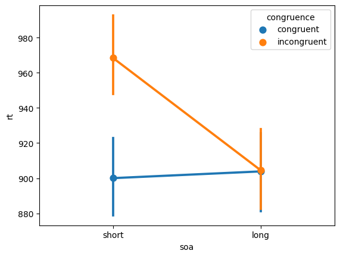

```python
sns.pointplot(data = df, x = 'soa', y = 'rt', hue = 'congruence')
```

Let's take a look at the individual trials.

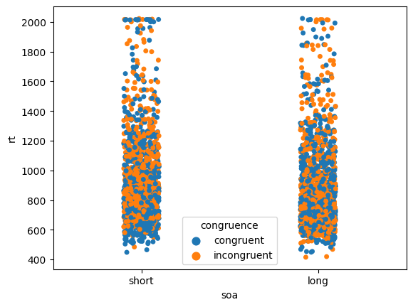

```python
sns.stripplot(data = df, x = 'soa', y = 'rt', hue = 'congruence')
```

Too many datapoints on top of each other. Can't see anything! Make a different plot:

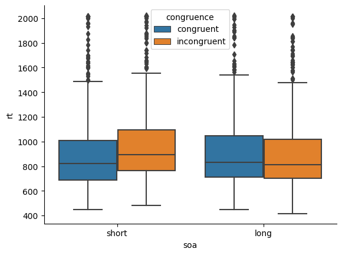

```python
sns.boxplot(data = df, x = 'soa', y = 'rt', hue = 'congruence')
sns.despine()
```

Hmm. There are some outliers. Let's try without them..

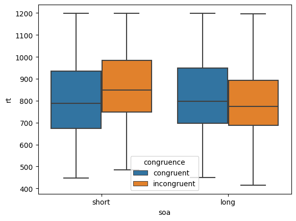

```python
sns.boxplot(data = df.loc[df['rt'] < 1200], x = 'soa', y = 'rt', hue = 'congruence')
```

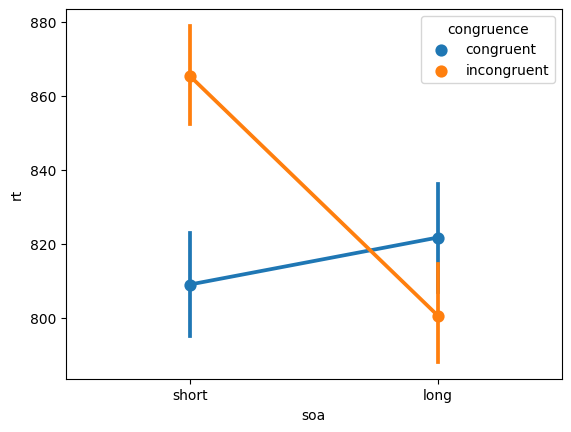

```python
sns.pointplot(data = df.loc[df['rt'] < 1200], x = 'soa', y = 'rt', hue = 'congruence')
```

How many rows of data did we throw away, when we got rid of the "outliers"?

```python
df.shape[0] - df.loc[df['rt'] < 1200].shape[0]
```

```
392
```

Did all the outliers come from the same person, or lots of different people?

```python
outliers = df[df['rt'] > 1200]
outliers['id'].unique()
```

```
array([799, 796, 795, 794, 789, 788, 784, 777, 772, 770, 769, 802, 800,
       798, 797, 792, 791, 786, 783, 779, 776, 773])
```

It looks like it was lots of different people. Did *all* the participants have some scores above 1200 ms? Let's compare the array of ID's of the participants in the full data set with the ID's of the participants who had some RT's longer than 1200 ms, to see if they are exactly the same:

```python
np.array_equal(outliers['id'].unique(), df['id'].unique())
```

```
False
```

Ok, so there were some participants who never took over 1200 ms. Who were they, and how many of them were there?

```python
speed_demons = [x for x in df['id'].unique() if x not in outliers['id'].unique()]
speed_demons
```

```
[785]
```

Ok, so there was actually only one participant who didn't have at least one "outlier" datapoint. Is there anything else unusual about this person's data? Let's plot participant 785's data together with everybody else's data (with outliers removed).

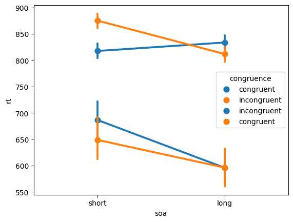

```python
sns.pointplot(data = df.loc[((df['rt'] < 1200) & (df['id'] != 785))],
              x = 'soa', y = 'rt',
              hue = 'congruence')
sns.pointplot(data = df.loc[df['id'] == 785], x = 'soa', y = 'rt', hue = 'congruence')
```

No, not really. The overall pattern is the same, they are just substantially faster than everybody else. What about their accuracy? Were they fast, but sloppy?

```python
def accuracy(data):
    correct = len(data[data['correct']== 1])
    errors = len(data[data['correct']== 0])
    percent_correct = round((correct / (correct + errors)) * 100, 2)
    return(percent_correct)
```

```python
accuracy(df.loc[df['id'] == 785])
```

```
74.17
```

```python
accuracy(df.loc[df['id'] != 785])
```

```
68.22
```

No, not only was this person faster than everybody else, they also made fewer mistakes. Now, what happens if we look at the data after removing the trials on which people made mistakes...?

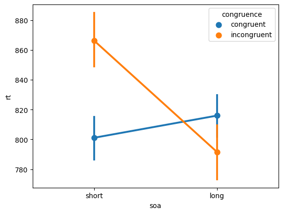

```python
sns.pointplot(data = df.loc[((df['rt'] < 1200) & (df['correct'] == 1))],
              x = 'soa', y = 'rt',
              hue = 'congruence')
```

Could there be any semantic priming effect in the incongruent data? That is, do "natural" primes prime "natural" targets, even when they are incongruent?

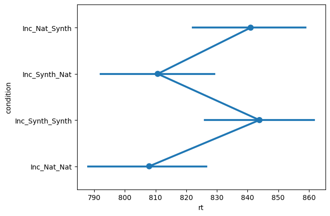

```python
sns.pointplot(data = df.loc[((df['rt'] < 1200) &
                             (df['correct'] == 1) &
                             (df['congruence'] == 'incongruent'))],
              y = 'condition',
              x = 'rt')
```

```python
natnatsynth = df[df['condition'] == 'Nat_Nat_Synth']
natnatsynth
```

[output not shown]

```python
natnatsynth = raw_a[raw_a['condition'] == 'Nat_Nat_Synth']
nns = pd.DataFrame(natnatsynth, columns = ['prime', 'target', 'congruence'])
nns
```

|  | prime | target | congruence |
| --- | --- | --- | --- |
| 53 | finch | SLOTH | incongruent |
| 176 | finch | SLOTH | incongruent |
| 301 | finch | SLOTH | incongruent |
| 408 | finch | SLOTH | incongruent |
| 520 | finch | SLOTH | incongruent |
| 639 | finch | SLOTH | incongruent |
| 764 | finch | SLOTH | incongruent |
| 876 | finch | SLOTH | incongruent |
| 1010 | finch | SLOTH | incongruent |
| 1140 | finch | SLOTH | incongruent |
| 1272 | finch | SLOTH | incongruent |
| 1368 | finch | SLOTH | incongruent |

```python
natnatsynth = raw_b[raw_b['condition'] == 'Nat_Nat_Synth']
nns = pd.DataFrame(natnatsynth, columns = ['prime', 'target', 'congruence'])
nns
#natnatsynth
```

|  | prime | target | congruence |
| --- | --- | --- | --- |
| 70 | finch | SLOTH | incongruent |
| 201 | finch | SLOTH | incongruent |
| 313 | finch | SLOTH | incongruent |
| 478 | finch | SLOTH | incongruent |
| 577 | finch | SLOTH | incongruent |
| 743 | finch | SLOTH | incongruent |
| 859 | finch | SLOTH | incongruent |
| 936 | finch | SLOTH | incongruent |
| 1075 | finch | SLOTH | incongruent |
| 1202 | finch | SLOTH | incongruent |
| 1358 | finch | SLOTH | incongruent |

Ah. It seems like there is one item I mislabled, the one where "finch" primes "SLOTH". That should be easy to fix...

From here on, it's up to you. Clean up my mess with finch/SLOTH, and do some appropriate analyses to get answers to the research questions...

```python
# fixing ethan's mistake
# had to google 'pandas change values in column based on condition' and got a good geeksforgeeks thing
df.loc[df['condition'] == 'Nat_Nat_Synth', 'condition'] = 'Inc_Nat_Nat'
```

```python
df.loc[df['condition'] == 'Inc_Nat_Synth']
```

|  | id | counter_balance | condition | rt | congruence | soa | correct |
| --- | --- | --- | --- | --- | --- | --- | --- |
| 19 | 799 | A | Inc_Nat_Synth | 1204 | incongruent | short | 1 |
| 24 | 799 | A | Inc_Nat_Synth | 999 | incongruent | short | 1 |
| 33 | 799 | A | Inc_Nat_Synth | 1166 | incongruent | short | 1 |
| 39 | 799 | A | Inc_Nat_Synth | 984 | incongruent | short | 1 |
| 45 | 799 | A | Inc_Nat_Synth | 669 | incongruent | short | 1 |
| ... | ... | ... | ... | ... | ... | ... | ... |
| 1340 | 773 | B | Inc_Nat_Synth | 876 | incongruent | short | 1 |
| 1344 | 773 | B | Inc_Nat_Synth | 1343 | incongruent | short | 0 |
| 1351 | 773 | B | Inc_Nat_Synth | 1853 | incongruent | short | 1 |
| 1354 | 773 | B | Inc_Nat_Synth | 1345 | incongruent | short | 1 |
| 1360 | 773 | B | Inc_Nat_Synth | 788 | incongruent | short | 0 |

345 rows × 7 columns

[figure not shown]

```python
sns.pointplot(data = df.loc[(df['rt'] < 1200) &
                             (df['correct'] == 1) &
                             (df['congruence'] == 'incongruent')],
              y = 'condition',
              x = 'rt')
```

Answering the RQ's

|  | T | dof | alternative | p-val | CI95% | cohen-d | BF10 | power |
| --- | --- | --- | --- | --- | --- | --- | --- | --- |
| T-test | -3.559221 | 1379 | two-sided | 0.000385 | [-53.52, -15.49] | 0.116639 | 16.382 | 0.991105 |

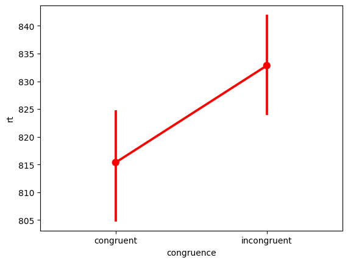

```python
#**Research question 1**: Can we observe a masked priming effect (in a non-native language)?

sns.pointplot(data = df.loc[df['rt'] < 1200], x = 'congruence', y = 'rt',  color = 'red')

group1 = df.loc[df['congruence'] == 'congruent']
group2 = df.loc[df['congruence'] == 'incongruent']

pg.ttest(group1['rt'], group2['rt'], paired = True)
```

|  | Contrast | congruence | A | B | Paired | Parametric | T | dof | alternative | p-unc | p-corr | p-adjust | BF10 | hedges |
| --- | --- | --- | --- | --- | --- | --- | --- | --- | --- | --- | --- | --- | --- | --- |
| 0 | congruence | - | congruent | incongruent | False | True | -3.063859 | 2758.0 | two-sided | 0.002206 | NaN | NaN | 4.529 | -0.116607 |
| 1 | soa | - | long | short | False | True | -2.665459 | 2758.0 | two-sided | 0.007733 | NaN | NaN | 1.46 | -0.101445 |
| 2 | congruence * soa | congruent | long | short | False | True | 0.242955 | 1378.0 | two-sided | 0.808077 | 1.000000 | bonf | 0.062 | 0.013073 |
| 3 | congruence * soa | incongruent | long | short | False | True | -3.989358 | 1378.0 | two-sided | 0.000070 | 0.000139 | bonf | 152.163 | -0.214663 |

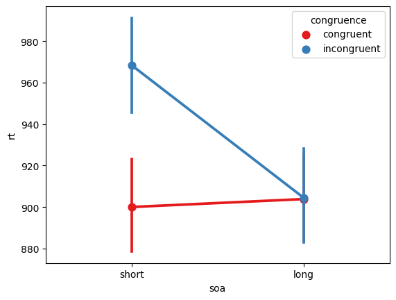

```python
#**Research question 2**: If there is a masked priming effect, does it increase, decrease, or stay the same after a short period of time (80 ms)?
sns.pointplot(data = df, x = 'soa', y = 'rt', hue = 'congruence', palette = 'Set1')

pg.rm_anova(data = df, dv = 'rt', within = ['congruence', 'soa'], subject = 'id')

pg.pairwise_ttests(data = df, dv = 'rt', between=["congruence", "soa"], padjust = 'bonf')
```

|  | Source | ddof1 | ddof2 | F | p-unc | p-GG-corr | ng2 | eps | sphericity | W-spher | p-spher |
| --- | --- | --- | --- | --- | --- | --- | --- | --- | --- | --- | --- |
| 0 | condition | 3 | 66 | 0.646098 | 0.588176 | 0.515151 | 0.003818 | 0.605667 | False | 0.385697 | 0.001417 |

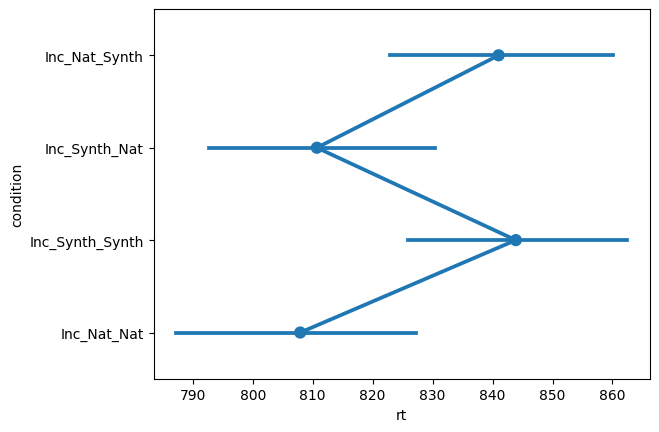

```python
#**Research question 3**: If there is a masked priming effect, is there also a semantic priming effect (in the incongruent pairs)?

sns.pointplot(data = df.loc[(df['rt'] < 1200) &
                             (df['correct'] == 1) &
                             (df['congruence'] == 'incongruent')],
              y = 'condition',
              x = 'rt')

pg.rm_anova(data = df.loc[df['congruence'] == 'incongruent'], dv = 'rt', within = ['condition'], subject = 'id')

#pg.pairwise_ttests(data = df[], dv = 'rt', between=["condition"], padjust = 'bonf')
```

|  | T | dof | alternative | p-val | CI95% | cohen-d | BF10 | power |
| --- | --- | --- | --- | --- | --- | --- | --- | --- |
| T-test | -0.484918 | 689 | two-sided | 0.627889 | [-34.11, 20.6] | 0.022583 | 0.048 | 0.09107 |

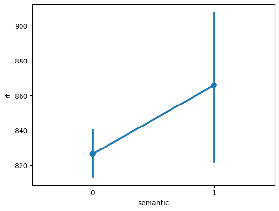

```python
df['semantic'] = np.where((df['condition'] == 'Inc_Nat_Nat') | (df['condition'] == 'Inc_Synth_Synth'), 1, 0)

sns.pointplot(data = df.loc[(df['rt'] < 1200) &
                             (df['correct'] == 1) &
                             (df['congruence'] == 'incongruent')],
             x = 'semantic', y = 'rt')


group1 = df.loc[(df['semantic'] == 0) & (df['congruence'] == 'incongruent')]
group2 = df.loc[(df['semantic'] == 1) & (df['congruence'] == 'incongruent')]

pg.ttest(group1['rt'], group2['rt'], paired = True)
```

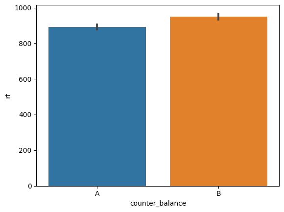

```python
# extra q's
# - did participants improve over time (both within blocks and over all trials)?



# - did it make a difference whether participants were in block A or block B (short SOA then long vs. long SOA then short)?

sns.barplot(data = df, x = 'counter_balance', y = 'rt')
```

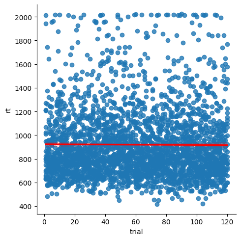

```python
sns.lmplot(data = df, x = 'trial', y = 'rt', line_kws={'color': 'red'})
```

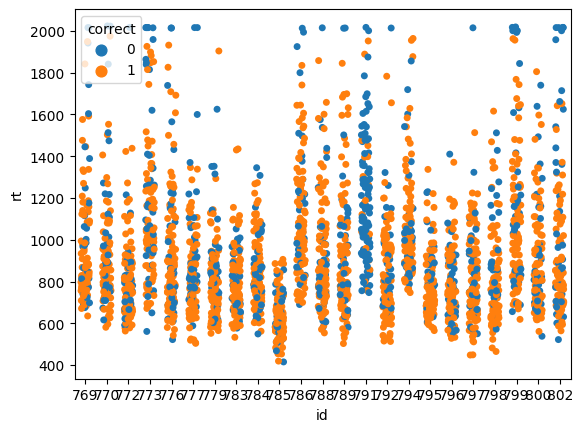

```python
sns.stripplot(data = df, x = 'id', y = 'rt', hue = 'correct', jitter = 0.2)
```

```python
slow_pokes = df.loc[df['rt'] > 1950]
slow_pokes['id'].value_counts()
```

```
799    7
802    7
773    7
770    3
791    3
794    2
789    2
777    2
769    2
786    2
776    2
788    1
772    1
797    1
792    1
Name: id, dtype: int64
```

```python
df['synth'] = df['condition'].str.endswith('Synth')
```

|  | T | dof | alternative | p-val | CI95% | cohen-d | BF10 | power |
| --- | --- | --- | --- | --- | --- | --- | --- | --- |
| T-test | -2.515991 | 1379 | two-sided | 0.011983 | [-43.95, -5.44] | 0.08341 | 0.709 | 0.872107 |

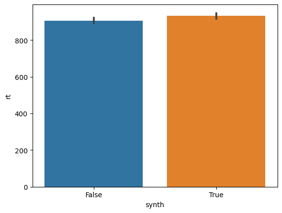

```python
sns.barplot(data = df, x = 'synth', y = 'rt')
group1 = df.loc[(df['synth'] == 0)]
group2 = df.loc[(df['synth'] == 1)]

pg.ttest(group1['rt'], group2['rt'], paired = True)
```